# MovieLens Project Questions

### Project - MovieLens Data Analysis

The GroupLens Research Project is a research group in the Department of Computer Science and Engineering at the University of Minnesota. The data is widely used for collaborative filtering and other filtering solutions. However, we will be using this data to act as a means to demonstrate our skill in using Python to “play” with data.

#### Domain

Internet and Entertainment

**Note that the project will need you to apply the concepts of groupby and merging extensively.**

```python
#Ghaidaa Al Kuhaili
```

```python
#https://github.com/GreatLearningAIML1/gl-pgp-aiml-uta-intl-may20-Ghaidaa-AlKuhaili/upload/master
```

#### 1. Import the necessary packages - 2.5 marks

```python
import pandas as pd
import numpy as np
import seaborn as sns
import matplotlib.pyplot as plt
%matplotlib inline
import warnings
warnings.filterwarnings('ignore')
```

#### 2. Read the 3 datasets into dataframes - 2.5 marks

```python
data_df=pd.read_csv('data.csv')
item_df=pd.read_csv('item.csv')
user_df=pd.read_csv('user.csv')
```

```python
#checking the data types
print(type(data_df))
print(type(item_df))
print(type(user_df))
```

```
<class 'pandas.core.frame.DataFrame'>
<class 'pandas.core.frame.DataFrame'>
<class 'pandas.core.frame.DataFrame'>
```

##### 3. Apply info, shape, describe, and find the number of missing values in the data - 5 marks

```python
#-----For Data dataframe--------:
#info
print('data info: ')
print('-------------------')
print(data_df.info())
#shape
print('data shape: ')
print('-------------------')
print(data_df.shape)
#describe
print('data description: ')
print('-------------------')
print(data_df.describe())
#number of missing values
print('number of null vales: ')
print('-------------------')
print(data_df.isnull().sum())
#-----For Item dataframe--------:
#info
print('Item info: ')
print('-------------------')
print(item_df.info())
#shape
print('Item shape: ')
print('-------------------')
print(item_df.shape)
#describe
print('Item description: ')
print('-------------------')
print(item_df.describe())
#number of missing values
print('number of null vales: ')
print('-------------------')
print(item_df.isnull().sum())

#-----For User dataframe--------:
#info
print('User info: ')
print('-------------------')
print(user_df.info())
#shape
print('User shape: ')
print('-------------------')
print(user_df.shape)
#describe
print('User description: ')
print('-------------------')
print(user_df.describe())
#number of missing values
print('number of null vales: ')
print('-------------------')
print(user_df.isnull().sum())
```

```
data info:
-------------------
<class 'pandas.core.frame.DataFrame'>
RangeIndex: 100000 entries, 0 to 99999
Data columns (total 4 columns):
user id      100000 non-null int64
movie id     100000 non-null int64
rating       100000 non-null int64
timestamp    100000 non-null int64
dtypes: int64(4)
memory usage: 3.1 MB
None
data shape:
-------------------
(100000, 4)
data description:
-------------------
            user id       movie id         rating     timestamp
count  100000.00000  100000.000000  100000.000000  1.000000e+05
mean      462.48475     425.530130       3.529860  8.835289e+08
std       266.61442     330.798356       1.125674  5.343856e+06
min         1.00000       1.000000       1.000000  8.747247e+08
25%       254.00000     175.000000       3.000000  8.794487e+08
50%       447.00000     322.000000       4.000000  8.828269e+08
75%       682.00000     631.000000       4.000000  8.882600e+08
max       943.00000    1682.000000       5.000000  8.932866e+08
number of null vales:
-------------------
user id      0
movie id     0
rating       0
timestamp    0
dtype: int64
Item info:
-------------------
<class 'pandas.core.frame.DataFrame'>
RangeIndex: 1681 entries, 0 to 1680
Data columns (total 22 columns):
movie id        1681 non-null int64
movie title     1681 non-null object
```

[output cut: 112 more lines]

```
mean   472.000000   34.051962
std    272.364951   12.192740
min      1.000000    7.000000
25%    236.500000   25.000000
50%    472.000000   31.000000
75%    707.500000   43.000000
max    943.000000   73.000000
number of null vales:
-------------------
user id       0
age           0
gender        0
occupation    0
zip code      0
dtype: int64
```

#### 4. Find the number of movies per genre using the item data - 5 marks

```python
# use sum on the default axis
#aggregation
item_df.columns
item_df[['unknown', 'Action',
       'Adventure', 'Animation', 'Childrens', 'Comedy', 'Crime', 'Documentary',
       'Drama', 'Fantasy', 'Film-Noir', 'Horror', 'Musical', 'Mystery',
       'Romance', 'Sci-Fi', 'Thriller', 'War', 'Western']].sum()
```

```
unknown          1
Action         251
Adventure      135
Animation       42
Childrens      122
Comedy         505
Crime          109
Documentary     50
Drama          725
Fantasy         22
Film-Noir       24
Horror          92
Musical         56
Mystery         61
Romance        247
Sci-Fi         101
Thriller       251
War             71
Western         27
dtype: int64
```

```python
item_df.head()
```

|  | movie id | movie title | release date | unknown | Action | Adventure | Animation | Childrens | Comedy | Crime | ... | Fantasy | Film-Noir | Horror | Musical | Mystery | Romance | Sci-Fi | Thriller | War | Western |
| --- | --- | --- | --- | --- | --- | --- | --- | --- | --- | --- | --- | --- | --- | --- | --- | --- | --- | --- | --- | --- | --- |
| 0 | 1 | Toy Story | 01-Jan-1995 | 0 | 0 | 0 | 1 | 1 | 1 | 0 | ... | 0 | 0 | 0 | 0 | 0 | 0 | 0 | 0 | 0 | 0 |
| 1 | 2 | GoldenEye | 01-Jan-1995 | 0 | 1 | 1 | 0 | 0 | 0 | 0 | ... | 0 | 0 | 0 | 0 | 0 | 0 | 0 | 1 | 0 | 0 |
| 2 | 3 | Four Rooms | 01-Jan-1995 | 0 | 0 | 0 | 0 | 0 | 0 | 0 | ... | 0 | 0 | 0 | 0 | 0 | 0 | 0 | 1 | 0 | 0 |
| 3 | 4 | Get Shorty | 01-Jan-1995 | 0 | 1 | 0 | 0 | 0 | 1 | 0 | ... | 0 | 0 | 0 | 0 | 0 | 0 | 0 | 0 | 0 | 0 |
| 4 | 5 | Copycat | 01-Jan-1995 | 0 | 0 | 0 | 0 | 0 | 0 | 1 | ... | 0 | 0 | 0 | 0 | 0 | 0 | 0 | 1 | 0 | 0 |

5 rows × 22 columns

#### 5. Find the movies that have more than one genre - 2.5 marks

```python
#hint: use sum on the axis = 1
new_item=item_df[['movie id','movie title']]
```

```python
new_item['Number of Genners']=item_df[['unknown', 'Action',
       'Adventure', 'Animation', 'Childrens', 'Comedy', 'Crime', 'Documentary',
       'Drama', 'Fantasy', 'Film-Noir', 'Horror', 'Musical', 'Mystery',
       'Romance', 'Sci-Fi', 'Thriller', 'War', 'Western']].sum(axis=1)
#finding the movies which have more than one genre
```

```python
new_item[new_item['Number of Genners']>1]
```

|  | movie id | movie title | Number of Genners |
| --- | --- | --- | --- |
| 0 | 1 | Toy Story | 3 |
| 1 | 2 | GoldenEye | 3 |
| 3 | 4 | Get Shorty | 3 |
| 4 | 5 | Copycat | 3 |
| 6 | 7 | Twelve Monkeys | 2 |
| 7 | 8 | Babe | 3 |
| 9 | 10 | Richard III | 2 |
| 10 | 11 | Seven (Se7en) | 2 |
| 11 | 12 | Usual Suspects, The | 2 |
| 13 | 14 | Postino, Il | 2 |
| 15 | 16 | French Twist (Gazon maudit) | 2 |
| 16 | 17 | From Dusk Till Dawn | 5 |
| 19 | 20 | Angels and Insects | 2 |
| 20 | 21 | Muppet Treasure Island | 5 |
| 21 | 22 | Braveheart | 3 |
| 22 | 23 | Taxi Driver | 2 |
| 23 | 24 | Rumble in the Bronx | 3 |
| 27 | 28 | Apollo 13 | 3 |
| 28 | 29 | Batman Forever | 4 |
| 30 | 31 | Crimson Tide | 3 |
| 32 | 33 | Desperado | 3 |
| 33 | 34 | Doom Generation, The | 2 |
| 34 | 35 | Free Willy 2: The Adventure Home | 3 |
| 35 | 36 | Mad Love | 2 |
| 37 | 38 | Net, The | 2 |
| 38 | 39 | Strange Days | 3 |
| 42 | 43 | Disclosure | 2 |
| 43 | 44 | Dolores Claiborne | 2 |
| 44 | 45 | Eat Drink Man Woman | 2 |
| 46 | 47 | Ed Wood | 2 |
| ... | ... | ... | ... |
| 1594 | 1596 | Nemesis 2: Nebula | 3 |
| 1595 | 1597 | Romper Stomper | 2 |
| 1596 | 1598 | City of Industry | 2 |
| 1602 | 1604 | He Walked by Night | 3 |
| 1606 | 1608 | Buddy | 3 |
| 1608 | 1610 | Truth or Consequences, N.M. | 3 |
| 1611 | 1613 | Tokyo Fist | 2 |
| 1612 | 1614 | Reluctant Debutante, The | 2 |
| 1613 | 1615 | Warriors of Virtue | 4 |
| 1616 | 1618 | King of New York | 2 |
| 1623 | 1625 | Nightwatch | 2 |
| 1624 | 1626 | Nobody Loves Me (Keiner liebt mich) | 2 |
| 1625 | 1627 | Wife, The | 2 |
| 1629 | 1631 | Slingshot, The | 2 |
| 1631 | 1633 | Á köldum klaka (Cold Fever) | 2 |
| 1636 | 1638 | Normal Life | 2 |
| 1644 | 1646 | Men With Guns | 2 |
| 1645 | 1647 | Hana-bi | 3 |
| 1647 | 1649 | Big One, The | 2 |
| 1649 | 1651 | Spanish Prisoner, The | 2 |
| 1653 | 1655 | Favor, The | 2 |
| 1654 | 1656 | Little City | 2 |
| 1655 | 1657 | Target | 2 |
| 1660 | 1662 | Rough Magic | 2 |
| 1661 | 1663 | Nothing Personal | 2 |
| 1667 | 1669 | MURDER and murder | 3 |
| 1668 | 1670 | Tainted | 2 |
| 1671 | 1673 | Mirage | 2 |
| 1677 | 1679 | B. Monkey | 2 |
| 1678 | 1680 | Sliding Doors | 2 |

849 rows × 3 columns

#### 6. Drop the movie where the genre is unknown - 2.5 marks

```python
item_df=item_df[item_df['unknown']!=1]
item_df.shape
```

```
(1680, 22)
```

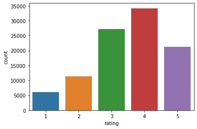

```python
sns.countplot(data_df['rating'])
plt.show()
```

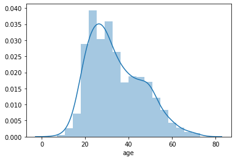

```python
sns.distplot(user_df['age'])
```

```python
item_df['release date'].head()
```

```
0    01-Jan-1995
1    01-Jan-1995
2    01-Jan-1995
3    01-Jan-1995
4    01-Jan-1995
Name: release date, dtype: object
```

```python
item_df['release year']=item_df['release date'].str[-4:].astype('int')
```

```python
item_df['release year'].head()
```

```
0    1995
1    1995
2    1995
3    1995
4    1995
Name: release year, dtype: int64
```

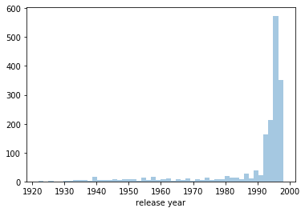

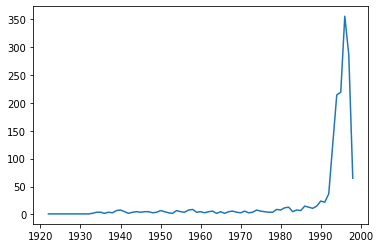

```python
# Hint : Use displot without kde for release year or line plot showing year wise count.
sns.distplot(item_df['release year'], kde=False)
plt.show()
print()
plt.plot(item_df.groupby('release year')['release year'].count())
```

```python
a = 'My*cat*is*brown'
print(a.split('*')[3])

#similarly, the release year needs to be taken out from release date

#also you can simply slice existing string to get the desired data, if we want to take out the colour of the cat

print(a[10:])
print(a[-5:])
```

[output not shown]

```python
#your answers here
```

### 8. Visualize how popularity of genres has changed over the years - 10 marks

Note that you need to use the number of releases in a year as a parameter of popularity of a genre

Hint

1: you need to reach to a data frame where the release year is the index and the genre is the column names (one cell shows the number of release in a year in one genre) or vice versa. Once that is achieved, you can either use univariate plots or can use the heatmap to visualise all the changes over the years in one go.

Hint 2: Use groupby on the relevant column and use sum() on the same to find out the nuumber of releases in a year/genre.

```python
genre_by_year=item_df.groupby('release year').sum()
genre_by_year=genre_by_year.drop(columns='movie id')
genre_by_year
```

| release year | unknown | Action | Adventure | Animation | Childrens | Comedy | Crime | Documentary | Drama | Fantasy | Film-Noir | Horror | Musical | Mystery | Romance | Sci-Fi | Thriller | War | Western |
| --- | --- | --- | --- | --- | --- | --- | --- | --- | --- | --- | --- | --- | --- | --- | --- | --- | --- | --- | --- |
| 1922 | 0 | 0 | 0 | 0 | 0 | 0 | 0 | 0 | 0 | 0 | 0 | 1 | 0 | 0 | 0 | 0 | 0 | 0 | 0 |
| 1926 | 0 | 0 | 0 | 0 | 0 | 0 | 0 | 0 | 1 | 0 | 0 | 0 | 0 | 0 | 0 | 0 | 0 | 0 | 0 |
| 1930 | 0 | 0 | 0 | 0 | 0 | 0 | 0 | 0 | 1 | 0 | 0 | 0 | 0 | 0 | 0 | 0 | 0 | 0 | 0 |
| 1931 | 0 | 0 | 0 | 0 | 0 | 0 | 1 | 0 | 0 | 0 | 1 | 0 | 0 | 0 | 0 | 0 | 1 | 0 | 0 |
| 1932 | 0 | 0 | 0 | 0 | 0 | 0 | 0 | 0 | 0 | 0 | 0 | 0 | 0 | 0 | 1 | 0 | 0 | 1 | 0 |
| 1933 | 0 | 0 | 0 | 0 | 0 | 1 | 0 | 0 | 0 | 0 | 0 | 0 | 0 | 0 | 1 | 0 | 0 | 1 | 0 |
| 1934 | 0 | 0 | 0 | 0 | 0 | 2 | 0 | 0 | 1 | 0 | 0 | 0 | 1 | 1 | 1 | 0 | 0 | 0 | 0 |
| 1935 | 0 | 0 | 0 | 0 | 0 | 2 | 0 | 0 | 0 | 0 | 0 | 1 | 1 | 0 | 1 | 0 | 1 | 0 | 0 |
| 1936 | 0 | 0 | 0 | 0 | 0 | 1 | 0 | 0 | 1 | 0 | 0 | 0 | 0 | 0 | 0 | 0 | 0 | 0 | 0 |
| 1937 | 0 | 0 | 0 | 1 | 1 | 2 | 0 | 0 | 1 | 0 | 0 | 0 | 3 | 0 | 2 | 0 | 0 | 0 | 0 |
| 1938 | 0 | 1 | 1 | 0 | 0 | 1 | 0 | 0 | 1 | 0 | 0 | 0 | 0 | 0 | 0 | 0 | 0 | 0 | 0 |
| 1939 | 0 | 0 | 1 | 0 | 2 | 2 | 1 | 0 | 5 | 0 | 0 | 0 | 1 | 0 | 2 | 0 | 0 | 1 | 0 |
| 1940 | 0 | 0 | 1 | 2 | 2 | 3 | 0 | 0 | 0 | 0 | 0 | 0 | 1 | 0 | 2 | 0 | 2 | 0 | 0 |
| 1941 | 0 | 0 | 0 | 1 | 1 | 0 | 0 | 0 | 3 | 0 | 1 | 0 | 1 | 1 | 1 | 0 | 0 | 0 | 0 |
| 1942 | 0 | 0 | 0 | 0 | 0 | 1 | 0 | 0 | 2 | 0 | 0 | 0 | 0 | 0 | 1 | 0 | 0 | 2 | 0 |
| 1943 | 0 | 0 | 1 | 0 | 0 | 1 | 0 | 0 | 1 | 0 | 0 | 0 | 0 | 1 | 0 | 0 | 0 | 1 | 1 |
| 1944 | 0 | 0 | 0 | 0 | 0 | 1 | 1 | 0 | 0 | 0 | 2 | 0 | 1 | 3 | 0 | 0 | 3 | 0 | 0 |
| 1945 | 0 | 0 | 0 | 1 | 1 | 0 | 0 | 0 | 1 | 0 | 0 | 1 | 1 | 1 | 1 | 0 | 1 | 0 | 0 |
| 1946 | 0 | 0 | 0 | 0 | 0 | 0 | 1 | 0 | 3 | 0 | 2 | 0 | 0 | 1 | 1 | 0 | 1 | 0 | 0 |
| 1947 | 0 | 0 | 1 | 0 | 0 | 0 | 1 | 0 | 1 | 0 | 2 | 0 | 0 | 0 | 2 | 0 | 0 | 0 | 1 |
| 1948 | 0 | 0 | 1 | 0 | 0 | 0 | 1 | 0 | 0 | 0 | 2 | 0 | 0 | 0 | 0 | 0 | 1 | 0 | 0 |
| 1949 | 0 | 0 | 0 | 0 | 1 | 0 | 0 | 0 | 2 | 0 | 0 | 0 | 1 | 1 | 0 | 0 | 1 | 0 | 0 |
| 1950 | 0 | 0 | 0 | 1 | 2 | 1 | 0 | 0 | 3 | 0 | 1 | 0 | 1 | 1 | 0 | 0 | 0 | 0 | 0 |
| 1951 | 0 | 1 | 1 | 1 | 1 | 0 | 0 | 0 | 2 | 0 | 0 | 0 | 2 | 0 | 2 | 1 | 0 | 1 | 0 |
| 1952 | 0 | 0 | 0 | 0 | 0 | 1 | 0 | 0 | 0 | 0 | 0 | 0 | 1 | 0 | 2 | 0 | 0 | 0 | 1 |
| 1953 | 0 | 0 | 0 | 0 | 0 | 2 | 0 | 0 | 0 | 0 | 0 | 0 | 1 | 0 | 1 | 0 | 0 | 0 | 0 |
| 1954 | 0 | 1 | 1 | 0 | 1 | 2 | 0 | 0 | 3 | 1 | 0 | 0 | 0 | 2 | 1 | 1 | 2 | 0 | 1 |
| 1955 | 0 | 0 | 0 | 0 | 0 | 1 | 0 | 0 | 3 | 0 | 0 | 0 | 0 | 0 | 1 | 0 | 1 | 0 | 1 |
| 1956 | 0 | 0 | 1 | 0 | 0 | 1 | 0 | 0 | 2 | 0 | 0 | 0 | 0 | 0 | 0 | 1 | 0 | 0 | 0 |
| 1957 | 0 | 0 | 0 | 0 | 1 | 2 | 0 | 0 | 5 | 0 | 0 | 0 | 1 | 0 | 2 | 0 | 0 | 2 | 0 |
| ... | ... | ... | ... | ... | ... | ... | ... | ... | ... | ... | ... | ... | ... | ... | ... | ... | ... | ... | ... |
| 1969 | 0 | 1 | 0 | 0 | 1 | 2 | 0 | 0 | 0 | 0 | 0 | 0 | 0 | 0 | 0 | 0 | 0 | 0 | 3 |
| 1970 | 0 | 0 | 0 | 1 | 1 | 1 | 0 | 0 | 1 | 0 | 0 | 0 | 0 | 0 | 0 | 0 | 0 | 2 | 0 |
| 1971 | 0 | 0 | 2 | 0 | 2 | 3 | 0 | 0 | 1 | 0 | 0 | 0 | 1 | 0 | 0 | 1 | 0 | 1 | 0 |
| 1972 | 0 | 1 | 0 | 0 | 0 | 1 | 1 | 0 | 2 | 0 | 0 | 0 | 0 | 0 | 0 | 0 | 0 | 0 | 0 |
| 1973 | 0 | 0 | 0 | 0 | 0 | 2 | 1 | 0 | 2 | 0 | 0 | 0 | 0 | 0 | 0 | 1 | 0 | 0 | 0 |
| 1974 | 0 | 1 | 1 | 0 | 1 | 4 | 1 | 0 | 2 | 0 | 1 | 2 | 0 | 1 | 0 | 0 | 1 | 0 | 0 |
| 1975 | 0 | 1 | 2 | 0 | 2 | 1 | 1 | 0 | 1 | 1 | 0 | 1 | 0 | 0 | 0 | 0 | 0 | 0 | 1 |
| 1976 | 0 | 0 | 0 | 0 | 0 | 0 | 0 | 0 | 2 | 0 | 0 | 3 | 0 | 0 | 0 | 0 | 0 | 0 | 0 |
| 1977 | 0 | 1 | 2 | 1 | 1 | 1 | 0 | 0 | 0 | 0 | 0 | 1 | 1 | 0 | 2 | 1 | 0 | 1 | 0 |
| 1978 | 0 | 1 | 0 | 0 | 0 | 2 | 0 | 0 | 1 | 0 | 0 | 1 | 1 | 0 | 1 | 0 | 0 | 1 | 0 |
| 1979 | 0 | 2 | 1 | 0 | 0 | 3 | 0 | 0 | 3 | 0 | 0 | 2 | 0 | 1 | 1 | 3 | 1 | 1 | 0 |
| 1980 | 0 | 2 | 1 | 0 | 0 | 3 | 0 | 0 | 3 | 0 | 0 | 2 | 1 | 0 | 2 | 1 | 0 | 1 | 0 |
| 1981 | 0 | 6 | 4 | 2 | 1 | 2 | 1 | 0 | 2 | 0 | 0 | 4 | 0 | 1 | 1 | 2 | 2 | 0 | 0 |
| 1982 | 0 | 1 | 1 | 0 | 1 | 3 | 0 | 0 | 6 | 1 | 1 | 2 | 3 | 0 | 1 | 3 | 0 | 1 | 0 |
| 1983 | 0 | 1 | 0 | 0 | 0 | 1 | 0 | 1 | 1 | 0 | 0 | 2 | 0 | 0 | 0 | 0 | 0 | 1 | 0 |
| 1984 | 0 | 2 | 1 | 0 | 0 | 1 | 1 | 0 | 5 | 0 | 0 | 1 | 1 | 1 | 0 | 2 | 2 | 1 | 0 |
| 1985 | 0 | 0 | 0 | 0 | 0 | 3 | 0 | 0 | 3 | 0 | 0 | 0 | 0 | 0 | 1 | 2 | 1 | 1 | 0 |
| 1986 | 0 | 5 | 3 | 1 | 1 | 3 | 0 | 0 | 8 | 0 | 0 | 2 | 0 | 0 | 2 | 3 | 2 | 3 | 0 |
| 1987 | 0 | 3 | 2 | 0 | 0 | 8 | 0 | 0 | 5 | 1 | 0 | 3 | 1 | 0 | 4 | 0 | 1 | 1 | 0 |
| 1988 | 0 | 2 | 2 | 2 | 1 | 3 | 0 | 1 | 3 | 0 | 0 | 0 | 0 | 0 | 2 | 1 | 3 | 0 | 1 |
| 1989 | 0 | 6 | 4 | 0 | 0 | 3 | 1 | 0 | 8 | 0 | 0 | 0 | 0 | 0 | 1 | 2 | 2 | 2 | 0 |
| 1990 | 0 | 7 | 1 | 0 | 1 | 6 | 3 | 2 | 12 | 0 | 1 | 1 | 0 | 0 | 4 | 0 | 4 | 0 | 2 |
| 1991 | 0 | 2 | 1 | 1 | 1 | 6 | 0 | 1 | 11 | 1 | 0 | 1 | 2 | 0 | 0 | 4 | 3 | 1 | 0 |
| 1992 | 0 | 8 | 1 | 2 | 1 | 12 | 5 | 0 | 14 | 0 | 0 | 6 | 1 | 1 | 7 | 3 | 5 | 2 | 1 |
| 1993 | 0 | 20 | 9 | 1 | 6 | 39 | 7 | 4 | 64 | 0 | 1 | 5 | 2 | 6 | 16 | 8 | 17 | 4 | 2 |
| 1994 | 0 | 30 | 13 | 4 | 15 | 82 | 8 | 9 | 97 | 3 | 0 | 8 | 2 | 2 | 35 | 7 | 25 | 7 | 6 |
| 1995 | 0 | 40 | 22 | 6 | 21 | 63 | 11 | 5 | 89 | 3 | 1 | 14 | 3 | 5 | 37 | 15 | 39 | 5 | 2 |
| 1996 | 0 | 44 | 24 | 9 | 21 | 108 | 21 | 18 | 170 | 6 | 1 | 11 | 9 | 6 | 38 | 15 | 47 | 9 | 2 |
| 1997 | 0 | 46 | 20 | 3 | 22 | 87 | 30 | 6 | 113 | 4 | 2 | 8 | 5 | 18 | 51 | 13 | 54 | 14 | 0 |
| 1998 | 0 | 12 | 3 | 0 | 1 | 13 | 7 | 3 | 33 | 1 | 2 | 4 | 1 | 3 | 11 | 5 | 18 | 0 | 0 |

71 rows × 19 columns

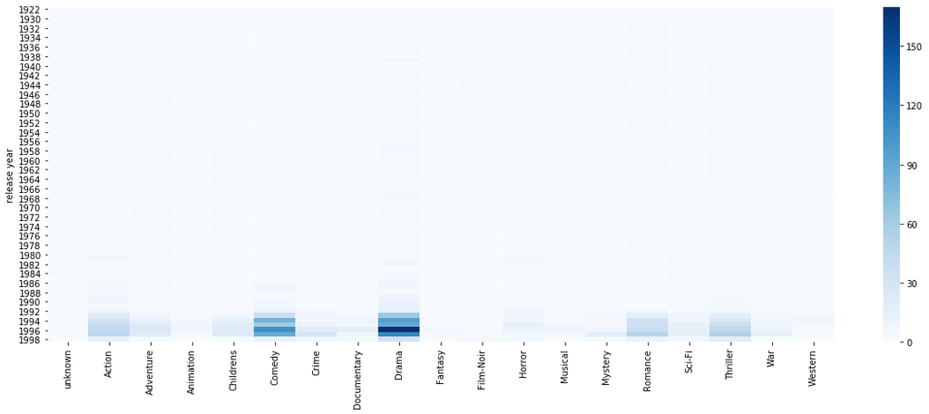

```python
plt.figure(figsize=(20,7))
sns.heatmap(genre_by_year,cmap="Blues")
plt.show()
```

### 9. Find the top 25 movies according to average ratings such that each movie has number of ratings more than 100 - 10 marks

Hint :

1. First find the movies that have more than 100 ratings(use merge, groupby and count). Extract the movie titles in a list.
2. Find the average rating of all the movies and sort them in the descending order. You will have to use the .merge() function to reach to a data set through which you can get the names and the average rating.
3. Use isin(list obtained from 1) to filter out the movies which have more than 100 ratings.

Note: This question will need you to research about groupby and apply your findings. You can find more on groupby on https://realpython.com/pandas-groupby/.

```python
check=user_df.merge(data_df, on='user id',how='inner')
```

```python
df=item_df.merge(check,on='movie id', how= 'inner')
```

```python
movies_more_100=df.groupby(['movie id', 'movie title'])['rating'].count().reset_index()
movies_more_100.head()
```

|  | movie id | movie title | rating |
| --- | --- | --- | --- |
| 0 | 1 | Toy Story | 452 |
| 1 | 2 | GoldenEye | 131 |
| 2 | 3 | Four Rooms | 90 |
| 3 | 4 | Get Shorty | 209 |
| 4 | 5 | Copycat | 86 |

```python
movie_list=list(movies_more_100[movies_more_100['rating']>100]['movie id'])
len(movie_list)
```

```
334
```

```python
avg_rating=df.groupby(['movie id', 'movie title'])['rating'].mean().sort_values(ascending=False).reset_index()
avg_rating.head()
```

|  | movie id | movie title | rating |
| --- | --- | --- | --- |
| 0 | 1293 | Star Kid | 5.0 |
| 1 | 1599 | Someone Else's America | 5.0 |
| 2 | 814 | Great Day in Harlem, A | 5.0 |
| 3 | 1122 | They Made Me a Criminal | 5.0 |
| 4 | 1201 | Marlene Dietrich: Shadow and Light ( | 5.0 |

```python
top_25=avg_rating[avg_rating['movie id'].isin(movie_list)].head(25)
```

```python
print(top_25.shape)
top_25.head()
```

```
(25, 3)
```

|  | movie id | movie title | rating |
| --- | --- | --- | --- |
| 15 | 408 | Close Shave, A | 4.491071 |
| 16 | 318 | Schindler's List | 4.466443 |
| 17 | 169 | Wrong Trousers, The | 4.466102 |
| 18 | 483 | Casablanca | 4.456790 |
| 20 | 64 | Shawshank Redemption, The | 4.445230 |

### 10. See gender distribution across different genres check for the validity of the below statements - 10 marks

- Men watch more drama than women
- Women watch more Sci-Fi than men
- Men watch more Romance than women
1. There is no need to conduct statistical tests around this. Just compare the percentages and comment on the validity of the above statements.
2. you might want ot use the .sum(), .div() function here.
3. Use number of ratings to validate the numbers. For example, if out of 4000 ratings received by women, 3000 are for drama, we will assume that 75% of the women watch drama.

```python
genre_by_gender=df.groupby('gender').sum().loc[:,'Action':'Western']
```

```python
genre_by_gender
```

| gender | Action | Adventure | Animation | Childrens | Comedy | Crime | Documentary | Drama | Fantasy | Film-Noir | Horror | Musical | Mystery | Romance | Sci-Fi | Thriller | War | Western |
| --- | --- | --- | --- | --- | --- | --- | --- | --- | --- | --- | --- | --- | --- | --- | --- | --- | --- | --- |
| F | 5442 | 3141 | 995 | 2232 | 8068 | 1794 | 187 | 11008 | 363 | 385 | 1197 | 1442 | 1314 | 5858 | 2629 | 5086 | 2189 | 371 |
| M | 20147 | 10612 | 2610 | 4950 | 21764 | 6261 | 571 | 28887 | 989 | 1348 | 4120 | 3512 | 3931 | 13603 | 10101 | 16786 | 7209 | 1483 |

```python
genre_by_gender['total']=genre_by_gender.sum(axis=1)
genre_by_gender.head()
```

| gender | Action | Adventure | Animation | Childrens | Comedy | Crime | Documentary | Drama | Fantasy | Film-Noir | Horror | Musical | Mystery | Romance | Sci-Fi | Thriller | War | Western | total |
| --- | --- | --- | --- | --- | --- | --- | --- | --- | --- | --- | --- | --- | --- | --- | --- | --- | --- | --- | --- |
| F | 5442 | 3141 | 995 | 2232 | 8068 | 1794 | 187 | 11008 | 363 | 385 | 1197 | 1442 | 1314 | 5858 | 2629 | 5086 | 2189 | 371 | 53701 |
| M | 20147 | 10612 | 2610 | 4950 | 21764 | 6261 | 571 | 28887 | 989 | 1348 | 4120 | 3512 | 3931 | 13603 | 10101 | 16786 | 7209 | 1483 | 158884 |

```python
genre_by_gender.div(genre_by_gender)
```

| gender | Action | Adventure | Animation | Childrens | Comedy | Crime | Documentary | Drama | Fantasy | Film-Noir | Horror | Musical | Mystery | Romance | Sci-Fi | Thriller | War | Western | total |
| --- | --- | --- | --- | --- | --- | --- | --- | --- | --- | --- | --- | --- | --- | --- | --- | --- | --- | --- | --- |
| F | 1.0 | 1.0 | 1.0 | 1.0 | 1.0 | 1.0 | 1.0 | 1.0 | 1.0 | 1.0 | 1.0 | 1.0 | 1.0 | 1.0 | 1.0 | 1.0 | 1.0 | 1.0 | 1.0 |
| M | 1.0 | 1.0 | 1.0 | 1.0 | 1.0 | 1.0 | 1.0 | 1.0 | 1.0 | 1.0 | 1.0 | 1.0 | 1.0 | 1.0 | 1.0 | 1.0 | 1.0 | 1.0 | 1.0 |

```python
#end of questins..
```